## Question 4: Which 5 year of range from 1980 - 2020 has the highest global sales?

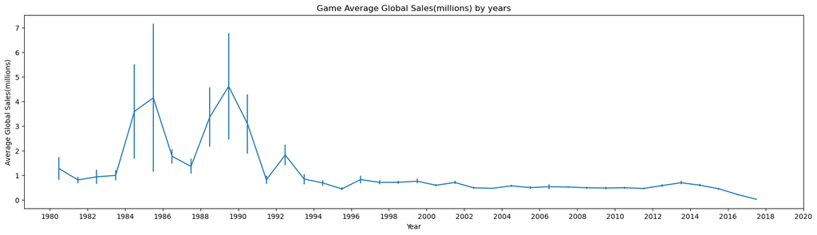

```python
# Visualization

plt.figure(figsize=(20,5))
# set bin edges, compute centers
bin_size = 1
xbin_edges = np.arange(1980, clean_df['Year'].max()+bin_size, bin_size)
xbin_centers = (xbin_edges + bin_size/2)[:-1]

# compute statistics in each bin
data_xbins = pd.cut(clean_df['Year'], xbin_edges, right = False, include_lowest = True)
y_means = clean_df['Global_Sales'].groupby(data_xbins).mean()
y_sems = clean_df['Global_Sales'].groupby(data_xbins).sem()  #std

# plot the summarized data
plt.errorbar(x = xbin_centers, y = y_means, yerr = y_sems)
plt.xlabel('Year')
plt.ylabel('Average Global Sales(millions)');
plt.xticks(range(1980,2021,2), range(1980,2021,2));
plt.title('Game Average Global Sales(millions) by years');
```

## Question 5: What is the relationship between sales numbers in 4 different main regions from 1980 - 2020?

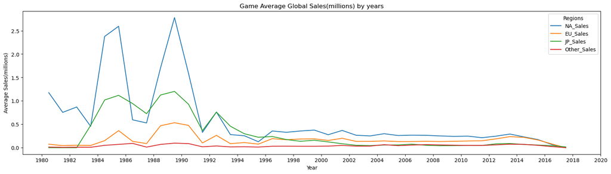

```python
# Visualization

plt.figure(figsize=(20,5))
# set bin edges, compute centers
bin_size = 1
xbin_edges = np.arange(1980, clean_df['Year'].max()+bin_size, bin_size)
xbin_centers = (xbin_edges + bin_size/2)[:-1]

# compute statistics in each bin
data_xbins = pd.cut(clean_df['Year'], xbin_edges, right = False, include_lowest = True)
y_means = clean_df['NA_Sales'].groupby(data_xbins).mean()
plt.errorbar(x = xbin_centers, y = y_means)
y_means = clean_df['EU_Sales'].groupby(data_xbins).mean()
plt.errorbar(x = xbin_centers, y = y_means)
y_means = clean_df['JP_Sales'].groupby(data_xbins).mean()
plt.errorbar(x = xbin_centers, y = y_means)
y_means = clean_df['Other_Sales'].groupby(data_xbins).mean()
plt.errorbar(x = xbin_centers, y = y_means)

# plot the summarized data
plt.xlabel('Year')
plt.ylabel('Average Sales(millions)');
plt.xticks(range(1980,2021,2), range(1980,2021,2));
plt.title('Game Average Global Sales(millions) by years');
plt.legend(title="Regions", labels=['NA_Sales','EU_Sales','JP_Sales','Other_Sales'])
```

We can see that North America have been sold more than most of the countries since 1980, but in the recent decade, every regions has been going down to near 0.25 millions at average due to the rising of mobile games.

## Question 6: What is the relation with Top 5 Platforms and years ?

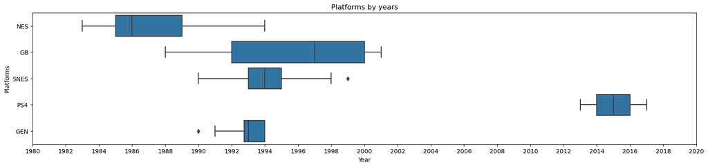

```python
# Visualization
#I only need the data from top platform
Top5platform_df = clean_df[clean_df['Platform'].isin(['PS4', 'SNES', 'GEN', 'NES', 'GB'])]
plt.figure(figsize=(20,4))
base_color = sb.color_palette()[0]
sb.boxplot(data = Top5platform_df, x = 'Year', y = 'Platform', color = base_color)
plt.xlabel('Year')
plt.ylabel('Platforms');
plt.xticks(range(1980,2021,2), range(1980,2021,2));
plt.title('Platforms by years');
```

We can see that there are 4 of top 5 platforms with high sales number happened before 2002, only one in the Top 5 (PS4), was popular after 2012.

```python
# import statmodel to analyze the relationship between independent variables and dependent variable.
import statsmodels.api as sm;
```

```python
df_new = clean_df.copy()
```

```python
# convert the categorical variable into 0,1
df_new[['Action', 'Adventure', 'Fighting', 'Misc', 'Platform(genre)', 'Puzzle',
       'Racing', 'Role-Playing', 'Shooter', 'Simulation', 'Sports',
       'Strategy']] = pd.get_dummies(clean_df['Genre'])
```

```python
# convert the categorical variable into 0,1
df_new[['2600', '3DO', '3DS', 'DC', 'DS', 'GB', 'GBA', 'GC', 'GEN', 'GG', 'N64',
       'NES', 'NG', 'PC', 'PS', 'PS2', 'PS3', 'PS4', 'PSP', 'PSV', 'SAT',
       'SCD', 'SNES', 'TG16', 'WS', 'Wii', 'WiiU', 'X360', 'XB', 'XOne']] = pd.get_dummies(clean_df['Platform'])
```

```python
# there are too many publishers in this dataset, so convert only top 5 publishers into 1,0
Nintendo_list = list(clean_df.query('Publisher == "Nintendo"').index)
RedOctane_list =list(clean_df.query('Publisher == "RedOctane"').index)
Sony_list =list(clean_df.query('Publisher == "Sony Computer Entertainment Europe"').index)
Microsoft_list =list(clean_df.query('Publisher == "Microsoft Game Studios"').index)
Imagic_list =list(clean_df.query('Publisher == "Imagic"').index)
df_new["Nintendo"] = 0
df_new["RedOctane"] = 0
df_new["Sony Computer Entertainment Europe"] = 0
df_new["Microsoft Game Studios"] = 0
df_new["Imagic"] = 0
```

```python
# give the top 5 publishers columns 0,1
for i in Nintendo_list:
    df_new['Nintendo'][i:i+1] = 1

for i in RedOctane_list:
    df_new['RedOctane'][i:i+1] = 1

for i in Sony_list:
    df_new['Sony Computer Entertainment Europe'][i:i+1] = 1

for i in Microsoft_list:
    df_new['Microsoft Game Studios'][i:i+1] = 1

for i in Imagic_list:
    df_new['Imagic'][i:i+1] = 1
```

```python
# visualize the coff of each categories of variables
# build a dataframe
d = {'coff': [0.83, 0.85,0.9771,1.7314,2.0433,0.3093, 0.2947,0.3293,1.7277,1.8499,0.1095, 0.1371, 0.1446, 0.3637, 0.3624], }
coff_df = pd.DataFrame(data=d)
```

```python
# give individual category names
coff_df['categories'] = " "
for i in range(0,5):
    coff_df[i:i+1]['categories']='Publisher'
for i in range(5,10):
    coff_df[i:i+1]['categories']='Platform'
for i in range(10,15):
    coff_df[i:i+1]['categories']='genre'
```

```python
# give individual places names
coff_df['places'] = " "
for i in range(0,15,5):
    coff_df[i:i+1]['places']='Top5'
for i in range(1,15,5):
    coff_df[i:i+1]['places']='Top4'
for i in range(2,15,5):
    coff_df[i:i+1]['places']='Top3'
for i in range(3,15,5):
    coff_df[i:i+1]['places']='Top2'
for i in range(4,15,5):
    coff_df[i:i+1]['places']='Top1'
```

[figure not shown]

```python
# Visualize
plt.figure(figsize=(10,5))
ax = sb.barplot(data = coff_df, x = 'places', y = 'coff', hue = 'categories')
ax.legend(loc = 2, ncol = 3, framealpha = 1, title = 'Variables');
plt.title('Coefficient correlation towards sales number by variables and places of each variables')
plt.xlabel("Top 5 places of average data in each variables");
```

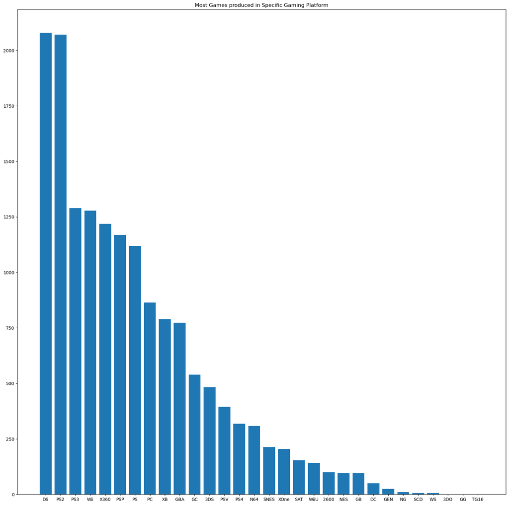

```python
import matplotlib.pyplot as plt

plt.figure(figsize=(20, 20))  # Set the figure size
plt.bar(df_new["Platform"].value_counts().index, df_new["Platform"].value_counts())  # Use df_new for data
plt.title("Most Games produced in Specific Gaming Platform")
plt.show()
```

## To get to know which genre sold the most globally

```python
df_new[["Genre","Global_Sales"]].groupby("Genre").sum()
```

| Genre | Global_Sales |
| --- | --- |
| Action | 1702.12 |
| Adventure | 225.82 |
| Fighting | 439.92 |
| Misc | 781.82 |
| Platform | 827.40 |
| Puzzle | 239.69 |
| Racing | 718.77 |
| Role-Playing | 919.36 |
| Shooter | 1013.45 |
| Simulation | 382.45 |
| Sports | 1298.40 |
| Strategy | 169.53 |